# EasyVisa_Full_Code_Siddhartha

### Model Building with oversampled data (DTree)

```python
# Fit SMOTE on train data(Synthetic Minority Oversampling Technique)
sm = SMOTE(sampling_strategy=1, k_neighbors=5, random_state=1)
X_train_over, y_train_over = sm.fit_resample(X_train, y_train)
```

```python
print("Before OverSampling, count of label '1': {}".format(sum(y_train == 1)))
print("Before OverSampling, count of label '0': {} \n".format(sum(y_train == 0)))

print("After OverSampling, count of label '1': {}".format(sum(y_train_over == 1)))
print("After OverSampling, count of label '0': {} \n".format(sum(y_train_over == 0)))

print("After OverSampling, the shape of train_X: {}".format(X_train_over.shape))
print("After OverSampling, the shape of train_y: {} \n".format(y_train_over.shape))
```

```
Before OverSampling, count of label '1': 11900
Before OverSampling, count of label '0': 5912

After OverSampling, count of label '1': 11900
After OverSampling, count of label '0': 11900

After OverSampling, the shape of train_X: (23800, 21)
After OverSampling, the shape of train_y: (23800,)
```

```
Training performance:
    Accuracy  Recall  Precision   F1
0       1.0     1.0        1.0  1.0
Testing performance:
    Accuracy    Recall  Precision        F1
0  0.654879  0.732013   0.746501  0.739186
```

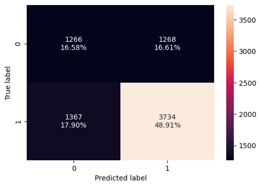

```python
#Fitting the model
d_tree_over = DecisionTreeClassifier(random_state=1)
d_tree_over.fit(X_train_over,y_train_over)

#Calculating different metrics
d_tree_model_train_perf_over=model_performance_classification_sklearn(d_tree_over,X_train_over,y_train_over)
print("Training performance:\n",d_tree_model_train_perf_over)
d_tree_model_test_perf_over=model_performance_classification_sklearn(d_tree_over,X_test,y_test)
print("Testing performance:\n",d_tree_model_test_perf_over)

#Creating confusion matrix
#confusion_matrix_sklearn(d_tree,X_train_over,y_train_over)
confusion_matrix_sklearn(d_tree_over,X_test,y_test)
```

- Using Oversampling on Minority class , did not change any performance score. Same overfit model as without oversampling.

### Model Building with undersampled data (DTree)

```python
# fit random under sampler on the train data
from imblearn.under_sampling import RandomUnderSampler
rus = RandomUnderSampler(random_state=1, sampling_strategy = 1)
X_train_un, y_train_un = rus.fit_resample(X_train, y_train)
```

```python
print("Before Under Sampling, count of label '1': {}".format(sum(y_train == 1)))
print("Before Under Sampling, count of label '0': {} \n".format(sum(y_train == 0)))

print("After Under Sampling, count of label '1': {}".format(sum(y_train_un == 1)))
print("After Under Sampling, count of label '0': {} \n".format(sum(y_train_un == 0)))

print("After Under Sampling, the shape of train_X: {}".format(X_train_un.shape))
print("After Under Sampling, the shape of train_y: {} \n".format(y_train_un.shape))
```

```
Before Under Sampling, count of label '1': 11900
Before Under Sampling, count of label '0': 5912

After Under Sampling, count of label '1': 5912
After Under Sampling, count of label '0': 5912

After Under Sampling, the shape of train_X: (11824, 21)
After Under Sampling, the shape of train_y: (11824,)
```

```
Training performance:
    Accuracy  Recall  Precision   F1
0       1.0     1.0        1.0  1.0
Testing performance:
    Accuracy    Recall  Precision      F1
0  0.623838  0.621643    0.77097  0.6883
```

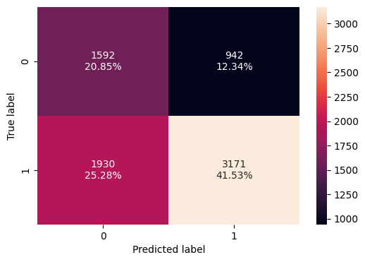

```python
#Fitting the model
d_tree_un = DecisionTreeClassifier(random_state=1)
d_tree_un.fit(X_train_un,y_train_un)

#Calculating different metrics
d_tree_model_train_perf_un=model_performance_classification_sklearn(d_tree_un,X_train_un,y_train_un)
print("Training performance:\n",d_tree_model_train_perf_un)
d_tree_model_test_perf_un=model_performance_classification_sklearn(d_tree_un,X_test,y_test)
print("Testing performance:\n",d_tree_model_test_perf_un)

#Creating confusion matrix
#confusion_matrix_sklearn(d_tree,X_train_over,y_train_over)
confusion_matrix_sklearn(d_tree_un,X_test,y_test)
```

## Random Forest Classifier

```
Training performance:
    Accuracy  Recall  Precision   F1
0       1.0     1.0        1.0  1.0
Testing performance:
    Accuracy    Recall  Precision        F1
0  0.721022  0.832974   0.768771  0.799586
```

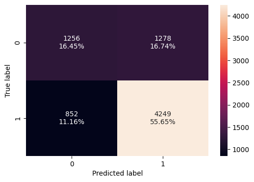

```python
#Fitting the model
rf_estimator = RandomForestClassifier(random_state=1)
rf_estimator.fit(X_train,y_train)

#Calculating different metrics
rf_estimator_model_train_perf=model_performance_classification_sklearn(rf_estimator,X_train,y_train)
print("Training performance:\n",rf_estimator_model_train_perf)
rf_estimator_model_test_perf=model_performance_classification_sklearn(rf_estimator,X_test,y_test)
print("Testing performance:\n",rf_estimator_model_test_perf)

#Creating confusion matrix
confusion_matrix_sklearn(rf_estimator,X_test,y_test)
```

- Random forest model is also overfitting the training data and Test F1 .79

# with oversample data

```
Training performance:
    Accuracy  Recall  Precision        F1
0  0.999944     1.0   0.999916  0.999958
Testing performance:
    Accuracy    Recall  Precision        F1
0  0.716045  0.815526   0.772229  0.793288
```

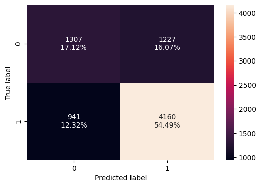

```python
#Fitting the model
rf_estimator_over = RandomForestClassifier(random_state=1)
rf_estimator_over.fit(X_train_over,y_train_over)

#Calculating different metrics
rf_estimator_model_train_perf_over=model_performance_classification_sklearn(rf_estimator_over,X_train,y_train)
print("Training performance:\n",rf_estimator_model_train_perf_over)
rf_estimator_model_test_perf_over=model_performance_classification_sklearn(rf_estimator_over,X_test,y_test)
print("Testing performance:\n",rf_estimator_model_test_perf_over)

#Creating confusion matrix
confusion_matrix_sklearn(rf_estimator_over,X_test,y_test)
```

# undersampling data

```
Training performance:
    Accuracy    Recall  Precision        F1
0  0.891871  0.838235     0.9999  0.911958
Testing performance:
    Accuracy    Recall  Precision        F1
0   0.68055  0.672417   0.817056  0.737714
```

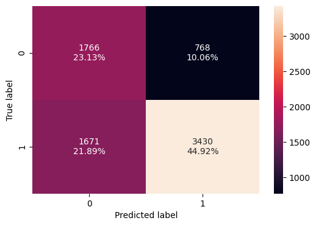

```python
#Fitting the model
rf_estimator_un = RandomForestClassifier(random_state=1)
rf_estimator_un.fit(X_train_un,y_train_un)

#Calculating different metrics
rf_estimator_model_train_perf_un=model_performance_classification_sklearn(rf_estimator_un,X_train,y_train)
print("Training performance:\n",rf_estimator_model_train_perf_un)
rf_estimator_model_test_perf_un=model_performance_classification_sklearn(rf_estimator_un,X_test,y_test)
print("Testing performance:\n",rf_estimator_model_test_perf_un)

#Creating confusion matrix
confusion_matrix_sklearn(rf_estimator_un,X_test,y_test)
```

- Same overfitting nature is found

# Bagging Classifier

```
Training performance:
    Accuracy    Recall  Precision        F1
0  0.984673  0.985882    0.99113  0.988499
Testing performance:
    Accuracy    Recall  Precision       F1
0  0.701244  0.779259   0.774854  0.77705
```

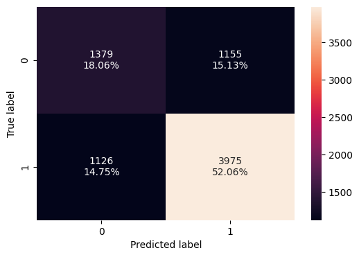

```python
#Fitting the model
bagging_classifier = BaggingClassifier(random_state=1)
bagging_classifier.fit(X_train,y_train)

#Calculating different metrics
bagging_classifier_model_train_perf=model_performance_classification_sklearn(bagging_classifier,X_train,y_train)
print("Training performance:\n", bagging_classifier_model_train_perf)
bagging_classifier_model_test_perf=model_performance_classification_sklearn(bagging_classifier,X_test,y_test)
print("Testing performance:\n", bagging_classifier_model_test_perf)

#Creating confusion matrix
confusion_matrix_sklearn(bagging_classifier,X_test,y_test)
```

# with oversampled data

```
Training performance:
    Accuracy    Recall  Precision        F1
0  0.988235  0.984622   0.991789  0.988193
Testing performance:
    Accuracy    Recall  Precision        F1
0  0.689718  0.752598   0.776183  0.764208
```

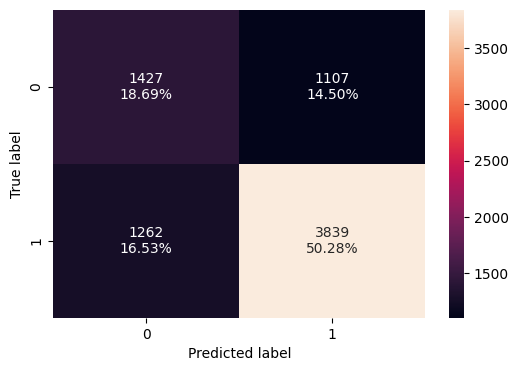

```python
#Fitting the model
bagging_classifier_over = BaggingClassifier(random_state=1)
bagging_classifier_over.fit(X_train_over,y_train_over)

#Calculating different metrics
bagging_classifier_model_train_perf_over=model_performance_classification_sklearn(bagging_classifier_over,X_train_over,y_train_over)
print("Training performance:\n", bagging_classifier_model_train_perf_over)
bagging_classifier_model_test_perf_over=model_performance_classification_sklearn(bagging_classifier_over,X_test,y_test)
print("Testing performance:\n", bagging_classifier_model_test_perf_over)

#Creating confusion matrix
confusion_matrix_sklearn(bagging_classifier_over,X_test,y_test)
```

# with undersampled data

```
Training performance:
    Accuracy    Recall  Precision        F1
0  0.980463  0.968369   0.992373  0.980224
Testing performance:
    Accuracy    Recall  Precision        F1
0  0.648723  0.615173   0.813586  0.700603
```

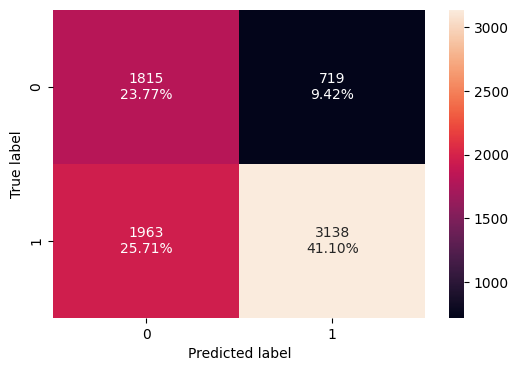

```python
#Fitting the model
bagging_classifier_un = BaggingClassifier(random_state=1)
bagging_classifier_un.fit(X_train_un,y_train_un)

#Calculating different metrics
bagging_classifier_model_train_perf_un=model_performance_classification_sklearn(bagging_classifier_un,X_train_un,y_train_un)
print("Training performance:\n", bagging_classifier_model_train_perf_un)
bagging_classifier_model_test_perf_un=model_performance_classification_sklearn(bagging_classifier_un,X_test,y_test)
print("Testing performance:\n", bagging_classifier_model_test_perf_un)

#Creating confusion matrix
confusion_matrix_sklearn(bagging_classifier_un,X_test,y_test)
```

- Similar Overfitting is observed with both undersampled and oversampled data

# AdaBoost Classifier

```
Training performance:
    Accuracy    Recall  Precision        F1
0  0.740568  0.891176   0.761252  0.821106
Testing performance:
    Accuracy    Recall  Precision        F1
0  0.737917  0.881396   0.763069  0.817975
```

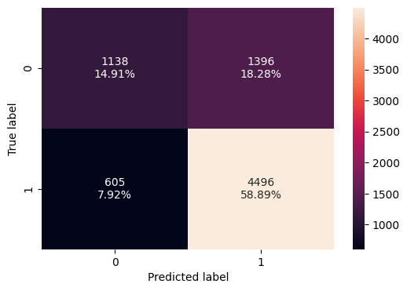

```python
#Fitting the model
ab_classifier = AdaBoostClassifier(random_state=1)
ab_classifier.fit(X_train,y_train)

#Calculating different metrics
ab_classifier_model_train_perf=model_performance_classification_sklearn(ab_classifier,X_train,y_train)
print("Training performance:\n", ab_classifier_model_train_perf)
ab_classifier_model_test_perf=model_performance_classification_sklearn(ab_classifier,X_test,y_test)
print("Testing performance:\n", ab_classifier_model_test_perf)

#Creating confusion matrix
confusion_matrix_sklearn(ab_classifier,X_test,y_test)
```

- Unlike the decision tree, random forest, or the bagging classifier; the AdaBoost classifier is not found to overfit the training data. **It is giving a generalized performance on the training & testing data with a F1 score 0.82 & 0.817**

# with oversampled & Understampled data as below

```
Training performance:
    Accuracy    Recall  Precision        F1
0  0.778361  0.866807   0.736523  0.796371
Testing performance:
    Accuracy    Recall  Precision       F1
0  0.737132  0.859635   0.772551  0.81377
```

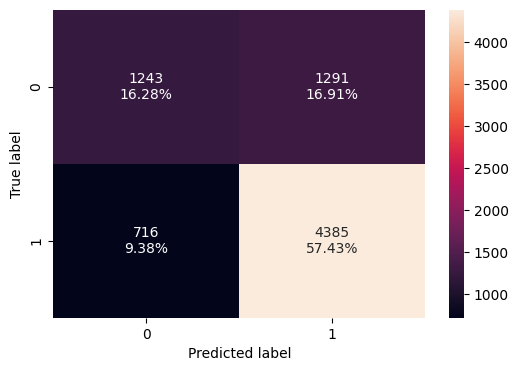

```python
#Fitting the model
ab_classifier_over = AdaBoostClassifier(random_state=1)
ab_classifier_over.fit(X_train_over,y_train_over)

#Calculating different metrics
ab_classifier_model_train_perf_over=model_performance_classification_sklearn(ab_classifier_over,X_train_over,y_train_over)
print("Training performance:\n", ab_classifier_model_train_perf_over)
ab_classifier_model_test_perf_over=model_performance_classification_sklearn(ab_classifier_over,X_test,y_test)
print("Testing performance:\n", ab_classifier_model_test_perf_over)

#Creating confusion matrix
confusion_matrix_sklearn(ab_classifier_over,X_test,y_test)
```

```
Training performance:
    Accuracy    Recall  Precision        F1
0  0.696719  0.705345   0.693382  0.699312
Testing performance:
    Accuracy    Recall  Precision        F1
0   0.69797  0.701039   0.820748  0.756185
```

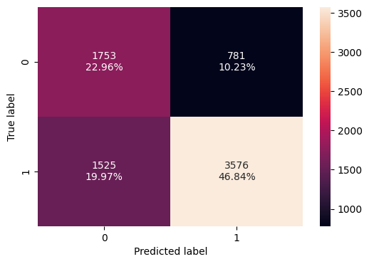

```python
#Fitting the model
ab_classifier_un = AdaBoostClassifier(random_state=1)
ab_classifier_un.fit(X_train_un,y_train_un)

#Calculating different metrics
ab_classifier_model_train_perf_un=model_performance_classification_sklearn(ab_classifier_un,X_train_un,y_train_un)
print("Training performance:\n", ab_classifier_model_train_perf_un)
ab_classifier_model_test_perf_un=model_performance_classification_sklearn(ab_classifier_un,X_test,y_test)
print("Testing performance:\n", ab_classifier_model_test_perf_un)

#Creating confusion matrix
confusion_matrix_sklearn(ab_classifier_un,X_test,y_test)
```

- F1 score performed better with original data vs the oversampled or undersampled data

# Gradient Boosting Classifier

```
Training performance:
    Accuracy    Recall  Precision        F1
0  0.757242  0.880504   0.783109  0.828956
Testing performance:
    Accuracy    Recall  Precision        F1
0  0.747741  0.867869   0.779539  0.821336
```

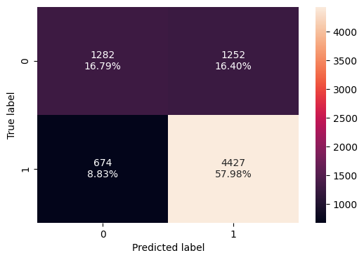

```python
#Fitting the model
gb_classifier = GradientBoostingClassifier(random_state=1)
gb_classifier.fit(X_train,y_train)

#Calculating different metrics
gb_classifier_model_train_perf=model_performance_classification_sklearn(gb_classifier,X_train,y_train)
print("Training performance:\n",gb_classifier_model_train_perf)
gb_classifier_model_test_perf=model_performance_classification_sklearn(gb_classifier,X_test,y_test)
print("Testing performance:\n",gb_classifier_model_test_perf)

#Creating confusion matrix
confusion_matrix_sklearn(gb_classifier,X_test,y_test)
```

- **The gradient boosting model is giving generalized performance on both the training and testing data with very high F1 scores of 0.82 and 0.82 respectively**

```
Training performance:
    Accuracy    Recall  Precision       F1
0  0.795924  0.856555   0.763921  0.80759
Testing performance:
    Accuracy    Recall  Precision        F1
0  0.746693  0.850421   0.787439  0.817719
```

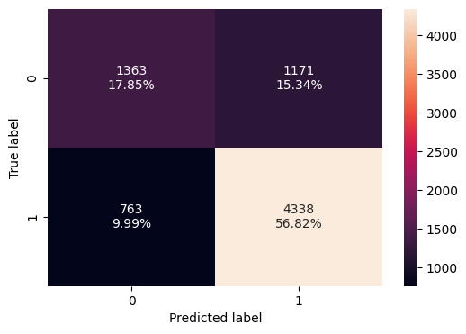

```python
#Fitting the model
gb_classifier_over = GradientBoostingClassifier(random_state=1)
gb_classifier_over.fit(X_train_over,y_train_over)

#Calculating different metrics
gb_classifier_model_train_perf_over=model_performance_classification_sklearn(gb_classifier_over,X_train_over,y_train_over)
print("Training performance:\n",gb_classifier_model_train_perf_over)
gb_classifier_model_test_perf_over=model_performance_classification_sklearn(gb_classifier_over,X_test,y_test)
print("Testing performance:\n",gb_classifier_model_test_perf_over)

#Creating confusion matrix
confusion_matrix_sklearn(gb_classifier_over,X_test,y_test)
```

```
Training performance:
    Accuracy    Recall  Precision       F1
0  0.719976  0.731732   0.714923  0.72323
Testing performance:
    Accuracy    Recall  Precision        F1
0  0.705305  0.709861   0.824641  0.762958
```

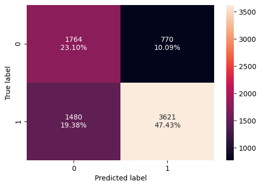

```python
#Fitting the model
gb_classifier_un = GradientBoostingClassifier(random_state=1)
gb_classifier_un.fit(X_train_un,y_train_un)

#Calculating different metrics
gb_classifier_model_train_perf_un=model_performance_classification_sklearn(gb_classifier_un,X_train_un,y_train_un)
print("Training performance:\n",gb_classifier_model_train_perf_un)
gb_classifier_model_test_perf_un=model_performance_classification_sklearn(gb_classifier_un,X_test,y_test)
print("Testing performance:\n",gb_classifier_model_test_perf_un)

#Creating confusion matrix
confusion_matrix_sklearn(gb_classifier_un,X_test,y_test)
```

- Original data showed better F1 consistency than over or undersampled data